# Act Report

## Introduction

The dataset to analyze is the tweet archive of Twitter user @dog_rates, also known as WeRateDogs. WeRateDogs is a Twitter account that rates people's dogs with a humorous comment about the dog. These ratings almost always have a denominator of 10. The numerators, though? Almost always greater than 10. 11/10, 12/10, 13/10, etc. WeRateDogs has over 4 million followers and has received international media coverage.

[figure not shown]

## Aim

The aim of this analysis is to draw insight from the data set and answer some basic and interesting questions,such as the language in which twitter users write their tweets the Most, which dog breed participates in the rating the most and Which days of the week do Twitter user tweet the most.

## Discussion

upon wrangling (Gathering, Assessing and cleaning) all data sets and merging them in one master data set, the following analysis was carried and insights gained.

### Assessing the dataset

The dataset contains 1,994 tweets of which all retweets have been removed.

### 1. Which language twitter users used the most to write their tweets ?.

Most Tweets are written in English as seen from the statistics below.

| Language | Number of Tweets |
| --- | --- |
| Englist (en) | 1987 |
| Dutch (nl) | 3 |
| Lingala (in) | 2 |
| Basque (eu) | 1 |
| Estonian (et) | 1 |

### 2. Which dog breed participates in the rating the most ?.

There are more Golden Retriever dogs bread (139) that participated in the rating.

### 3. Which days of the week do Twitter users tweet the most ?.

Finally looking closely, we can see the at Most Tweets were written on Mondays (321), then on Wednesdays (301). An average of 285 tweets are written every day.

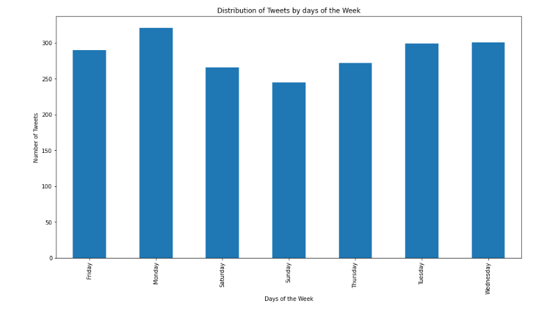

### 4. Which maturity stage are most of the dogs?.

From the chart we can see that most dogs (203) are of the pupper maturity stage

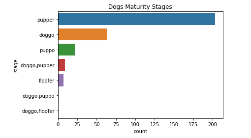